# Estadística bayesiana, modelización y máxima verosimilitud

Carlos J. Gil Bellosta

2016-02-12

# Estadística bayesiana

# Probabilidad condicional (y total)

- Las mujeres tienen una menor tasa de accidentes que los hombres: $P(\text{accidente}|M) < P(\text{accidente}|H)$.
- Ejercicio:
  - $P(a|H) = 0.1$
  - $P(a|M) = 0.05$
  - 45% de mujeres ($P(M)$ = 45%)
  - ¿Cuál es la probabilidad de que haya un accidente?

# Teorema de Bayes: el problema

- Ejercicios:
  - Si hay un accidente, ¿cuál es la probabilidad de que el involucrado sea mujer?
  - En un país hay ciudadanos de dos razas, A (10%) y B (90%). El 60% de los delincuentes (1% del total) son de raza A. ¿Cuál es la probabilidad de que un ciudadano de raza A (B) sea delincuente?
- El problema es obtener $P(B|A)$ a partir de $P(B|A)$

# Teorema de Bayes

$$P(X | A) = \frac{P(A|X)P(X)}{P(A)}$$

¡Sirve para *darle la vuelta* a las probabilidades condicionales!

Demostración: se basa en la definición
$$P(A \cap X) = P(A | X) P(X)$$

# Pruebas de hipótesis: recordatorio

- Tiramos una moneda 100 veces y obtenemos 60 caras
- ¿Compatible con `p=.5`?
- Podemos hacer una prueba de hipótesis clásica con hipótesis nula ($H_0$): `p=0.5`
- De otra manera: ¿cómo de raras son 60 caras en 100 tiradas si `p=.5`?

# Prueba de hipótesis mediante remuestreos

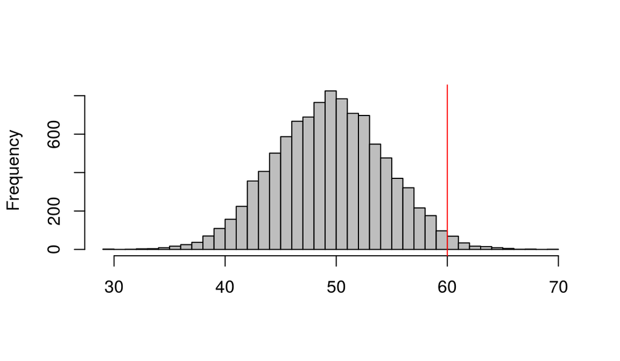

```r
N <- 100; n <- 60; p <- 0.5
muestras <- rbinom(10000, N, p)
hist(muestras, breaks = 30, col = "gray", main = "", xlab = "")
abline(v = n, col = "red")
```

# El p-valor: proporción de muestras que superan el valor obtenido

```r
mean(muestras >= n)
```

```
## [1] 0.025
```

El p-valor es la proporción de muestras que exceden (en este caso) el valor obtenido.

Conceptualmente, es $P(D|H_0)$, la probabilidad de tus datos dada la hipótesis nula.

# Estadística bayesiana y pruebas de hipótesis

- Recordad que el p-valor era $P(D|H_0)$.
- ¡Pero eso no es lo importante!
- Lo importante es $P(H_0|D)$.
- Es decir, lo *verosímil* que es la hipótesis nula $H_0$ a la vista de los datos.
- La estadística bayesiana trata de medir $P(H_0|D)$ usando el teorema de Bayes, es decir,

$$P(H_0 | D) = \frac{P(D|H_0) P(H_0)}{P(D)}$$

# rstan: código

```r
library(rstan)

stanmodelcode <- '
data {
  int<lower=1> N;
  int n;
}

parameters {
  real<lower=0, upper = 1> p;
}

model {
  // priori no informativa
  p ~ beta(1,1);

  // verosimilitud
  n ~ binomial(N, p);
}
'

fit <- stan(model_code = stanmodelcode,
            data = list(N = 100, n = 60),
            iter = 12000, warmup = 2000,
            chains = 4, thin = 10)
```

# rstan: resultados

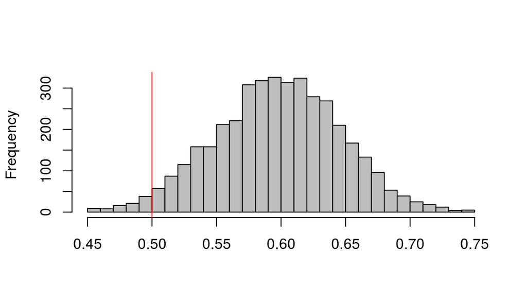

```r
res <- as.data.frame(fit)
hist(res$p, breaks = 30, col = "gray", main = "", xlab = "")
abline(v = 0.5, col = "red")
```

# Modelización estadística

# Modelos y realidad

- Los científicos (físicos, economistas, sicólogos, etc.) plantean modelos teóricos
- Un modelo teórico es también una *hipótesis* (o modelo hipotético, si se prefiere)
- Los modelos teóricos serán *válidos* si se adecúan a la realidad (a través de datos)
- Además de eso, la estadística te puede decir cuánto (o en qué medida)

# Estadística y aprendizaje automático

- El aprendizaje automático busca predecir, crear cajas negras
- ¡La predicción puede ser (y de hecho, es) útil en sí!
- Pero generalmente el aprendizaje automático no presta atención a la interpretabilidad
- Ejemplos:
  - El aprendizaje automático ha sido capaz de crear una máquina que juega (¡muy bien!) al Go
  - La estadística mide cuánto más de X se va a vender si el precio baja un 10%

# Introducción al modelo lineal

- Nos interesa una variable X (p.e., log del salario)
- Podemos hacer como el periódico: media de X, $\mu$
- Pero sabemos que hay variabilidad alrededor de X: si la suponemos normal, $X \sim N(\mu, \sigma)$
- Pero el salario depende de muchas variables (conocidas y desconocidas). Por eso
  $$X_i \sim N(\mu_i, \sigma)$$
  donde $X_i$ es el (log)salario del sujeto $i$ y $\mu_i$ depende de variables $x_{i1}, \dots, x_{in}$.

# Introducción al modelo lineal (cont.)

- Si suponemos que $\mu_i = a_0 + a_1 x_{i1} + \dots + a_n x_{in}$, tenemos el *modelo lineal* (o regresión lineal).
- El problema: encontrar los valores $a_j$ *óptimos*.

# Introducción a la regresión logística

- Nos interesa una variable X (p.e., que alguien esté en paro)
- Podemos hacer como el periódico: la tasa de paro es $p$.
- Se podría pensar que $X \sim \text{Bernoulli}(p)$
- Pero la tasa de paro depende de muchas variables (conocidas y desconocidas). Por eso podemos pensar que
  $$X_i \sim \text{Bernoulli}(p_i)$$
  donde $p_i$ depende de variables $x_{i1}, \dots, x_{in}$.

# Introducción a la regresión logística (cont.)

- Si suponemos que $p_i = f(a_0 + a_1 x_{i1} + \dots + a_n x_{in})$, tenemos la regresión logística.
- Nota: como $0 \le p \le 1$, $f$ tiene que ser una función que *mapee* en dicho rango.
- Se usa
  $$f(x) = \frac{\exp(x)}{1 + \exp(x)}$$
- El problema, de nuevo: encontrar los valores $a_j$ *óptimos*.

# Introducción al modelo lineal generalizado

- X puede ser:
  - Una variable continua (regresión lineal)
  - Una probabilidad (regresión logística)
  - Un conteo (modelo de Poisson / binomial negativa)
  - (Y algunos más que aparecen menos frecuentemente)
- Los parámetros de la distribución dependen del sujeto a través de funciones lineales de variables predictoras

# El problema

- Determinar si la realidad se ajusta a la especificación estadística
  - ¿Son independientes los sujetos?
  - ¿Siguen realmente esa distribución teórica?
- Encontrar los coeficientes de esa relación lineal
- Determinar si el modelo se ajusta o no razonablemente a los datos

# Otros modelos probabilísticos

- El modelo lineal generalizado no agota los modelos estadísticos. Los hay para series temporales, medidas repetidas, geoestadística, etc.
- Pero todos se basan en una especificación probabilística de los datos
- Y en todos están presentes los problemas mencionados arriba:
  - Encontrar los coeficientes o parámetros
  - Determinar si el modelo se ajusta o no razonablemente a los datos

# Máxima verosimilitud

# Máxima verosimilitud: valor más verosímil del parámetro

- Máxima verosimilitud: dar por bueno el valor del parámetro que hace más probable el resultado.
- Conceptualmente, es sencillo y las implicaciones son poderosas.
- ¡Una de las ideas más notables del s. XX!

# Un ejemplo con monedas

- 100 tiradas, 60 caras
- ¿Cuál es el valor *más verosímil* de $p$?
- Podemos construir la *función de verosimilitud*,
  $$l(p) = {100 \choose 60}p^{60} (1-p)^{40}$$
  que nos da la probabilidad en función del parámetro $p$.
- Es una función que nos enseñaron a maximizar en bachillerato: derivar respecto a $p$, etc.

# La función de verosimilitud

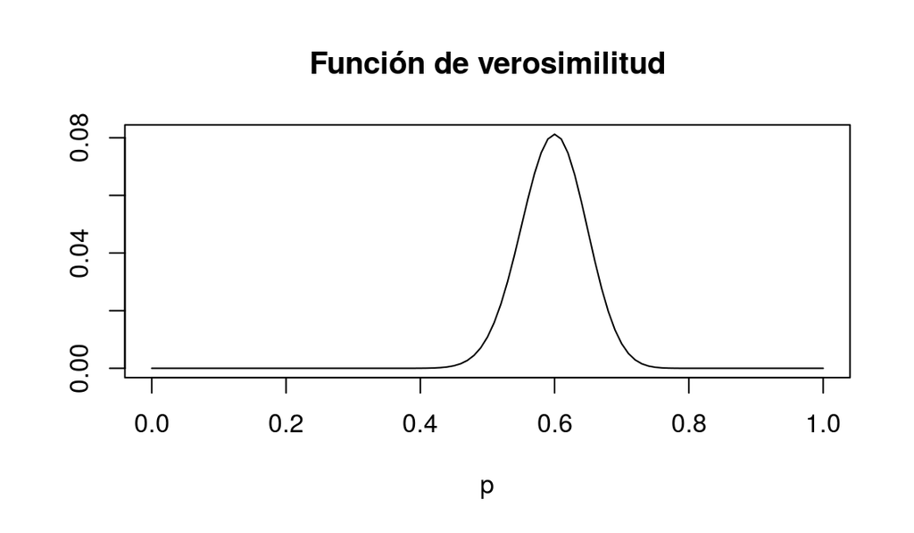

```r
curve(dbinom(60, 100, x), from = 0, to = 1,
      xlab = "p", ylab = "", main = "Función de verosimilitud")
```

# Notas sobre la función de verosimilitud

- Es un producto porque las observaciones (tiradas) son *independientes*
- Si no son independientes, la verosimilitud existe… pero es (mucho) más complicada
- Siendo un producto, tomar logaritmos ayuda (sobre todo cuando hay que derivar, etc.): el máximo de $f(x)$ está en el mismo valor que el de $\log(f(x))$.
- Ejercicio: ¿os atrevéis a buscar el máximo de $l(p)$ a mano?

# Un ejemplo con bombillas

- Tienes 100 bombillas que en un banco de pruebas han estado encendidas $n_i$ horas cada una.
- Se supone que tienen una *vida exponencial*:
  $$P(D \le t) = \int_0^t \lambda \exp(-\lambda x) dx$$
- La verosimilitud es $l(\lambda) = \prod_i \lambda \exp(-\lambda n_i)$
- Ejercicio: ¿cuál es la estimación del parámetro por máxima verosimilitud?

# Máxima verosimilitud en el modelo lineal

- En el modelo lineal la función de verosimilitud es
  $$l(a_i) = \prod \Phi(y_i - \mu_i, \sigma),$$
  donde $\mu_i = a_0 + a_1 x_{i1} + \dots + a_n x_{in}$ y $\Phi = \frac{1}{\sigma\sqrt{2\pi}} \exp\left(\frac{-(y - \mu)^2}{2\sigma^2}\right)$
- Desarrollando, queda
  $$l(a_i) = \left(\frac{1}{\sigma\sqrt{2\pi}}\right)^n \exp\left( \frac{-\sum(y_i-\mu_i)^2}{{2\sigma^2}}\right)$$

# MV en el modelo lineal (cont.)

- Simplificando, i.e., tomando logs e ignorando lo que no depende de $a_i$, queda
  $$-\sum_i (y_i - (a_0 + a_1 x_{i1} + \dots + a_n x_{in}))^2$$
- Maximzar lo anterior es equivalente a minimizar
  $$\sum_i (y_i - (a_0 + a_1 x_{i1} + \dots + a_n x_{in}))^2,$$
  que es la *función de pérdida*.
- Por eso, al algoritmo se le llama *mínimos cuadrados*.

# Mínimos cuadrados, gráficamente

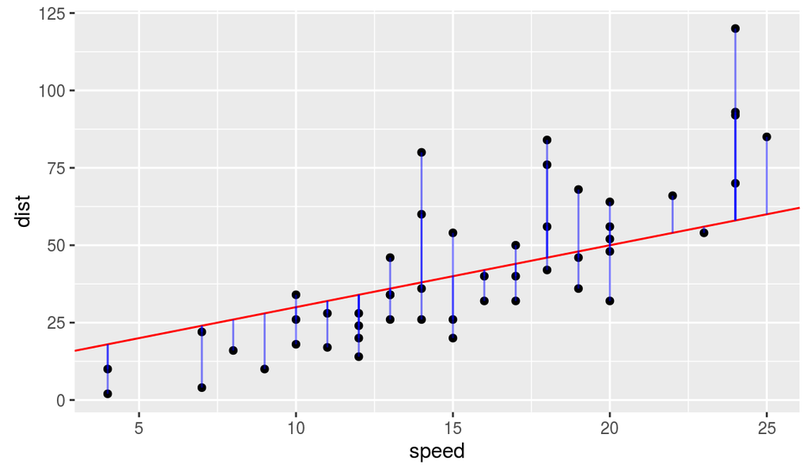

# Funciones de pérdida

- A partir de la verosimilitud para el modelo lineal hemos derivado la función de pérdida

$$L(a_i) = \sum_i (y_i - f_{a_j}(x_i))^2$$

- Muchos modelos más allá del lineal se ajustan minimizando funciones de pérdida como esa.
- O variantes tales como

$$L(a_i) = \sum_i |y_i - f_{a_j}(x_i)|$$
o
$$L(a_i) = \sum_i (y_i - f_{a_i}(x_i))^2 + \lambda \sum_j a_j^2$$

# Optimización

- Si $n$ es grande y $f_{a_i}$ es complicada, minimizar la pérdida es *imposible*.
- Incluso con `optim` y similares.
- Hacen falta ideas *ad hoc*, es decir,
  - *Atajos* para llegar al mínimo (p.e., `lm` o `glm`)
  - Heurísticas (p.e., los árboles de regresión, `gbm`, aprendizaje *reforzado* en redes neuronales, etc.)

# Modelización bayesiana

# Modelización bayesiana

- Es una alternativa a la máxima verosimilitud / optimización de funciones de pérdida
- Está basada en la estructura probabilística del modelo
- Calcula $P(\beta|D)$, es decir, la distribución de los parámetros a la vista de los datos
- Permite incluir información *a priori* en los modelos

# Información a priori

- Estamos en el siglo XXI
- ¡Ya sabemos mucho sobre muchos problemas!
- ¿Hay que empezar de cero en cada uno de ellos?
- ¿Cómo se manifiesta la información *a priori*?
  - Se sabe que un coeficiente tiene que estar en un rango determinado
  - Se sabe que el efecto de una intervención no puede ser superior a cierto umbral
  - Etc.

# Creación de modelos bayesianos

- Determinar la estructura probabilística del problema
- Identificar la información *a priori*
- Traducirlo a código de `rstan`
- Correr las cadenas
- Interpretar los resultados